# OCN683_HW1

## (4) So far we have examined the effect of the rat removal, but we have not considered the role of kipuka size, or the role of food availability (which is influenced in part by kipuka size). Make a new model that adds kipuka area and arthopod biomass as predictors, and include interactions that test whether the treatment effect depends on these additional predictors. Report F-tests and effects plots. How do the results of this model differ from the model in #3? How do you interpret the results at this stage?

```r
all_lm <- lm(foraging_ht_m ~ species * rat_removal * log_kipuka * log_arth_bm, data = bird)
summary(all_lm)
```

```
##
## Call:
## lm(formula = foraging_ht_m ~ species * rat_removal * log_kipuka *
##     log_arth_bm, data = bird)
##
## Residuals:
##      Min       1Q   Median       3Q      Max
## -11.8421  -2.3301   0.0051   2.5145  11.1463
##
## Coefficients:
##                                                         Estimate Std. Error
## (Intercept)                                               7.1148     0.9971
## speciesHAAM                                              -2.1872     2.2158
## speciesIIWI                                              -1.8424     3.6817
## speciesJAWE                                               6.5238     3.0442
## rat_removaluntreated                                      5.2650     1.3133
## log_kipuka                                                6.3609     0.7246
## log_arth_bm                                               4.5497     0.8063
## speciesHAAM:rat_removaluntreated                          6.3626     3.4593
## speciesIIWI:rat_removaluntreated                         18.3428     5.9508
## speciesJAWE:rat_removaluntreated                         -2.7484     5.7795
## speciesHAAM:log_kipuka                                    1.2600     1.4007
## speciesIIWI:log_kipuka                                    1.3212     2.0111
## speciesJAWE:log_kipuka                                   -5.2900     2.5010
## rat_removaluntreated:log_kipuka                          -3.5968     0.9989
## speciesHAAM:log_arth_bm                                   0.5974     1.7391
## speciesIIWI:log_arth_bm                                   3.0684     1.9864
## speciesJAWE:log_arth_bm                                  -8.1839     2.0206
## rat_removaluntreated:log_arth_bm                         -5.3963     0.9745
## log_kipuka:log_arth_bm                                   -2.9579     0.5414
## speciesHAAM:rat_removaluntreated:log_kipuka              -6.1691     2.2002
## speciesIIWI:rat_removaluntreated:log_kipuka             -12.1350     3.3599
## speciesJAWE:rat_removaluntreated:log_kipuka               2.2147     5.2413
## speciesHAAM:rat_removaluntreated:log_arth_bm             -3.9826     2.4781
## speciesIIWI:rat_removaluntreated:log_arth_bm             -7.3926     3.2963
## speciesJAWE:rat_removaluntreated:log_arth_bm             12.2170    10.3349
## speciesHAAM:log_kipuka:log_arth_bm                       -0.6200     0.9979
## speciesIIWI:log_kipuka:log_arth_bm                       -1.8631     1.1097
## speciesJAWE:log_kipuka:log_arth_bm                        6.9456     1.7661
## rat_removaluntreated:log_kipuka:log_arth_bm               3.6743     0.6429
```

[output cut: 27 more lines]

```
## speciesIIWI:rat_removaluntreated:log_arth_bm             -2.243 0.025377 *
## speciesJAWE:rat_removaluntreated:log_arth_bm              1.182 0.237756
## speciesHAAM:log_kipuka:log_arth_bm                       -0.621 0.534685
## speciesIIWI:log_kipuka:log_arth_bm                       -1.679 0.093829 .
## speciesJAWE:log_kipuka:log_arth_bm                        3.933 9.65e-05 ***
## rat_removaluntreated:log_kipuka:log_arth_bm               5.715 1.94e-08 ***
## speciesHAAM:rat_removaluntreated:log_kipuka:log_arth_bm   2.237 0.025743 *
## speciesIIWI:rat_removaluntreated:log_kipuka:log_arth_bm   2.933 0.003519 **
## speciesJAWE:rat_removaluntreated:log_kipuka:log_arth_bm  -2.029 0.043059 *
## ---
## Signif. codes:  0 '***' 0.001 '**' 0.01 '*' 0.05 '.' 0.1 ' ' 1
##
## Residual standard error: 3.489 on 474 degrees of freedom
## Multiple R-squared:  0.518,  Adjusted R-squared:  0.4865
## F-statistic: 16.43 on 31 and 474 DF,  p-value: < 2.2e-16
```

```r
Anova(all_lm)
```

```
## Anova Table (Type II tests)
##
## Response: foraging_ht_m
##                                            Sum Sq  Df  F value    Pr(>F)
## species                                     145.8   3   3.9933 0.0079390 **
## rat_removal                                  33.0   1   2.7126 0.1002242
## log_kipuka                                 2452.0   1 201.4765 < 2.2e-16 ***
## log_arth_bm                                  33.1   1   2.7179 0.0998913 .
## species:rat_removal                          58.1   3   1.5912 0.1906753
## species:log_kipuka                          260.7   3   7.1399 0.0001067 ***
## rat_removal:log_kipuka                       13.2   1   1.0824 0.2987011
## species:log_arth_bm                          39.5   3   1.0812 0.3566651
## rat_removal:log_arth_bm                      41.3   1   3.3975 0.0659209 .
## log_kipuka:log_arth_bm                       28.9   1   2.3708 0.1242901
## species:rat_removal:log_kipuka               83.4   3   2.2850 0.0780977 .
## species:rat_removal:log_arth_bm              77.6   3   2.1246 0.0962739 .
## species:log_kipuka:log_arth_bm              194.2   3   5.3188 0.0013001 **
## rat_removal:log_kipuka:log_arth_bm          946.1   1  77.7395 < 2.2e-16 ***
## species:rat_removal:log_kipuka:log_arth_bm  208.6   3   5.7120 0.0007583 ***
## Residuals                                  5768.8 474
## ---
## Signif. codes:  0 '***' 0.001 '**' 0.01 '*' 0.05 '.' 0.1 ' ' 1
```

This new model above includes the log transformed kipuka size and arthopod biomass along with their interactions with bird species and rat treatments. The purpose being to look at the effects of rat removal on foraging height thatʻs dependant on both habitat size and food availability. Based on the Anova table, log_kipuka was highly significant (F=201.48, p=<2.2e-16) while log_arth_bm was not significant (F=2.72, p=0.10). As for significant interactions:

- Species: log_kipuka
- species:log_kipuka:log_arth_bm
- rat_removal:log_kipuka:log_arth_bm
- species:rat_removal:log_kipuka:log_arth_bm

Were all found as significant factors and interactions.

```r
all_lm <- lm(foraging_ht_m ~ species * rat_removal * log_kipuka * log_arth_bm, data = bird)
summary(all_lm)
```

```
##
## Call:
## lm(formula = foraging_ht_m ~ species * rat_removal * log_kipuka *
##     log_arth_bm, data = bird)
##
## Residuals:
##      Min       1Q   Median       3Q      Max
## -11.8421  -2.3301   0.0051   2.5145  11.1463
##
## Coefficients:
##                                                         Estimate Std. Error
## (Intercept)                                               7.1148     0.9971
## speciesHAAM                                              -2.1872     2.2158
## speciesIIWI                                              -1.8424     3.6817
## speciesJAWE                                               6.5238     3.0442
## rat_removaluntreated                                      5.2650     1.3133
## log_kipuka                                                6.3609     0.7246
## log_arth_bm                                               4.5497     0.8063
## speciesHAAM:rat_removaluntreated                          6.3626     3.4593
## speciesIIWI:rat_removaluntreated                         18.3428     5.9508
## speciesJAWE:rat_removaluntreated                         -2.7484     5.7795
## speciesHAAM:log_kipuka                                    1.2600     1.4007
## speciesIIWI:log_kipuka                                    1.3212     2.0111
## speciesJAWE:log_kipuka                                   -5.2900     2.5010
## rat_removaluntreated:log_kipuka                          -3.5968     0.9989
## speciesHAAM:log_arth_bm                                   0.5974     1.7391
## speciesIIWI:log_arth_bm                                   3.0684     1.9864
## speciesJAWE:log_arth_bm                                  -8.1839     2.0206
## rat_removaluntreated:log_arth_bm                         -5.3963     0.9745
## log_kipuka:log_arth_bm                                   -2.9579     0.5414
## speciesHAAM:rat_removaluntreated:log_kipuka              -6.1691     2.2002
## speciesIIWI:rat_removaluntreated:log_kipuka             -12.1350     3.3599
## speciesJAWE:rat_removaluntreated:log_kipuka               2.2147     5.2413
## speciesHAAM:rat_removaluntreated:log_arth_bm             -3.9826     2.4781
## speciesIIWI:rat_removaluntreated:log_arth_bm             -7.3926     3.2963
## speciesJAWE:rat_removaluntreated:log_arth_bm             12.2170    10.3349
## speciesHAAM:log_kipuka:log_arth_bm                       -0.6200     0.9979
## speciesIIWI:log_kipuka:log_arth_bm                       -1.8631     1.1097
## speciesJAWE:log_kipuka:log_arth_bm                        6.9456     1.7661
## rat_removaluntreated:log_kipuka:log_arth_bm               3.6743     0.6429
```

[output cut: 27 more lines]

```
## speciesIIWI:rat_removaluntreated:log_arth_bm             -2.243 0.025377 *
## speciesJAWE:rat_removaluntreated:log_arth_bm              1.182 0.237756
## speciesHAAM:log_kipuka:log_arth_bm                       -0.621 0.534685
## speciesIIWI:log_kipuka:log_arth_bm                       -1.679 0.093829 .
## speciesJAWE:log_kipuka:log_arth_bm                        3.933 9.65e-05 ***
## rat_removaluntreated:log_kipuka:log_arth_bm               5.715 1.94e-08 ***
## speciesHAAM:rat_removaluntreated:log_kipuka:log_arth_bm   2.237 0.025743 *
## speciesIIWI:rat_removaluntreated:log_kipuka:log_arth_bm   2.933 0.003519 **
## speciesJAWE:rat_removaluntreated:log_kipuka:log_arth_bm  -2.029 0.043059 *
## ---
## Signif. codes:  0 '***' 0.001 '**' 0.01 '*' 0.05 '.' 0.1 ' ' 1
##
## Residual standard error: 3.489 on 474 degrees of freedom
## Multiple R-squared:  0.518,  Adjusted R-squared:  0.4865
## F-statistic: 16.43 on 31 and 474 DF,  p-value: < 2.2e-16
```

```r
Anova(all_lm)
```

```
## Anova Table (Type II tests)
##
## Response: foraging_ht_m
##                                            Sum Sq  Df  F value    Pr(>F)
## species                                     145.8   3   3.9933 0.0079390 **
## rat_removal                                  33.0   1   2.7126 0.1002242
## log_kipuka                                 2452.0   1 201.4765 < 2.2e-16 ***
## log_arth_bm                                  33.1   1   2.7179 0.0998913 .
## species:rat_removal                          58.1   3   1.5912 0.1906753
## species:log_kipuka                          260.7   3   7.1399 0.0001067 ***
## rat_removal:log_kipuka                       13.2   1   1.0824 0.2987011
## species:log_arth_bm                          39.5   3   1.0812 0.3566651
## rat_removal:log_arth_bm                      41.3   1   3.3975 0.0659209 .
## log_kipuka:log_arth_bm                       28.9   1   2.3708 0.1242901
## species:rat_removal:log_kipuka               83.4   3   2.2850 0.0780977 .
## species:rat_removal:log_arth_bm              77.6   3   2.1246 0.0962739 .
## species:log_kipuka:log_arth_bm              194.2   3   5.3188 0.0013001 **
## rat_removal:log_kipuka:log_arth_bm          946.1   1  77.7395 < 2.2e-16 ***
## species:rat_removal:log_kipuka:log_arth_bm  208.6   3   5.7120 0.0007583 ***
## Residuals                                  5768.8 474
## ---
## Signif. codes:  0 '***' 0.001 '**' 0.01 '*' 0.05 '.' 0.1 ' ' 1
```

```r
ggeffect(all_lm)
```

```
## $species
## # Predicted values of foraging_ht_m
##
## species | Predicted |       95% CI
## ----------------------------------
## APAP    |     16.90 | 16.47, 17.34
## HAAM    |     14.96 | 14.07, 15.85
## IIWI    |     17.76 | 16.36, 19.17
## JAWE    |     19.78 | 13.54, 26.03
##
##
## $rat_removal
## # Predicted values of foraging_ht_m
##
## rat_removal | Predicted |       95% CI
## --------------------------------------
## treated     |     16.90 | 16.40, 17.40
## untreated   |     16.77 | 15.99, 17.54
##
##
## $log_kipuka
## # Predicted values of foraging_ht_m
##
## log_kipuka | Predicted |       95% CI
## -------------------------------------
##       0.00 |     13.42 | 12.18, 14.66
##       0.40 |     14.32 | 13.31, 15.33
##       0.60 |     14.77 | 13.87, 15.67
##       1.00 |     15.67 | 14.98, 16.37
##       1.40 |     16.58 | 16.06, 17.10
##       1.60 |     17.03 | 16.56, 17.49
##       2.00 |     17.93 | 17.49, 18.37
##       2.60 |     19.28 | 18.65, 19.92
```

```
##
## Not all rows are shown in the output. Use `print(..., n = Inf)` to show
##   all rows.
```

```
##
## $log_arth_bm
## # Predicted values of foraging_ht_m
##
## log_arth_bm | Predicted |       95% CI
## --------------------------------------
##        0.00 |     16.26 | 15.59, 16.93
##        0.50 |     16.44 | 15.92, 16.96
##        1.50 |     16.79 | 16.32, 17.25
##        2.00 |     16.96 | 16.38, 17.55
##        2.50 |     17.14 | 16.38, 17.90
##        3.00 |     17.31 | 16.36, 18.27
##        3.50 |     17.49 | 16.33, 18.65
##        5.00 |     18.02 | 16.21, 19.82
```

```
##
## Not all rows are shown in the output. Use `print(..., n = Inf)` to show
##   all rows.
```

```
##
## attr(,"class")
## [1] "ggalleffects" "list"
## attr(,"model.name")
## [1] "all_lm"
```

[output not shown]

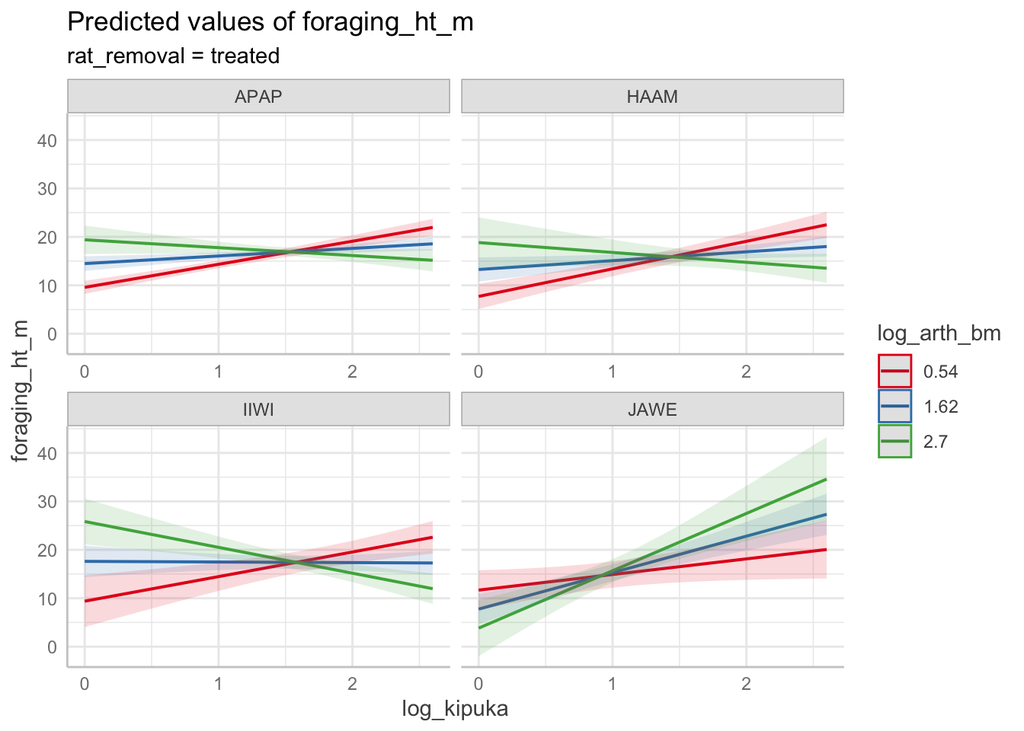

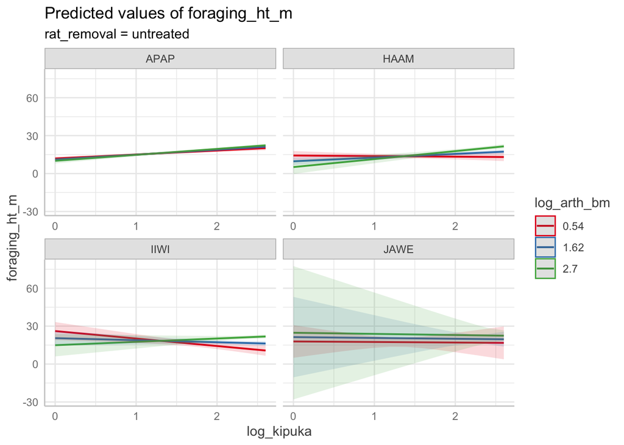

```r
# Generate effects for the model
effects_plot <- ggpredict(all_lm, terms = c("log_kipuka", "log_arth_bm", "species", "rat_removal"))

# Plot the effects
plot(effects_plot)
```

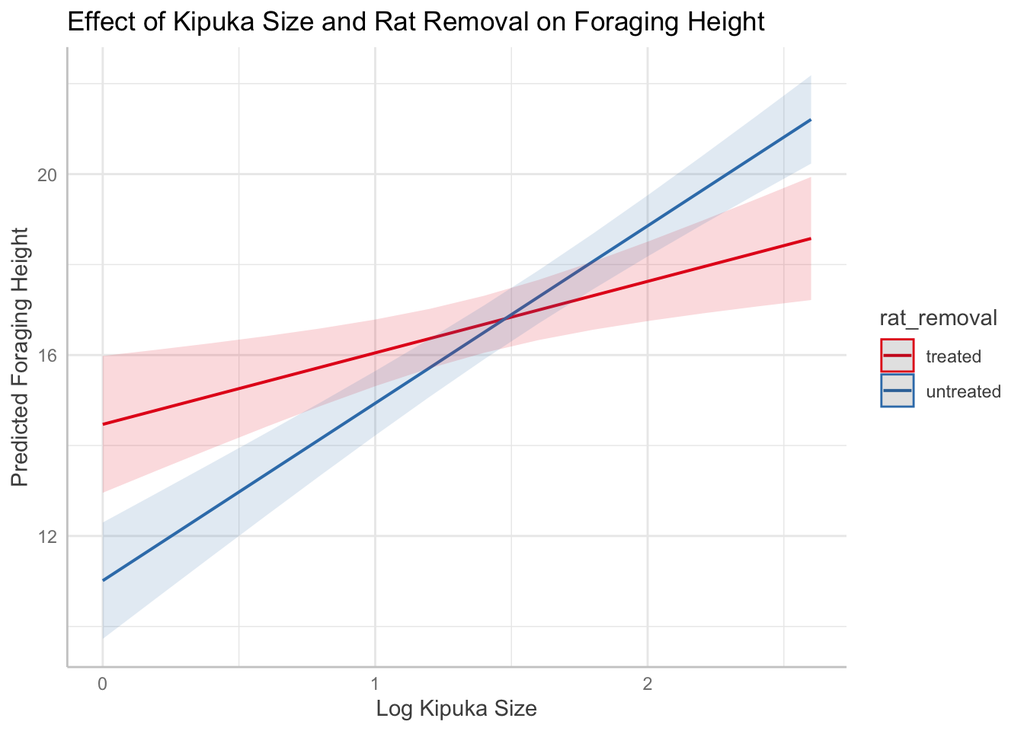

```r
#Focused interactions between significant factors
#log_kipuka with rat_removal interaction (SHowing the relationship between kipuka size and foraging height)
kipuka_rat_effects <- ggpredict(all_lm, terms = c("log_kipuka", "rat_removal"))

plot(kipuka_rat_effects) +
  ggtitle("Effect of Kipuka Size and Rat Removal on Foraging Height") +
  xlab("Log Kipuka Size") +
  ylab("Predicted Foraging Height")
```

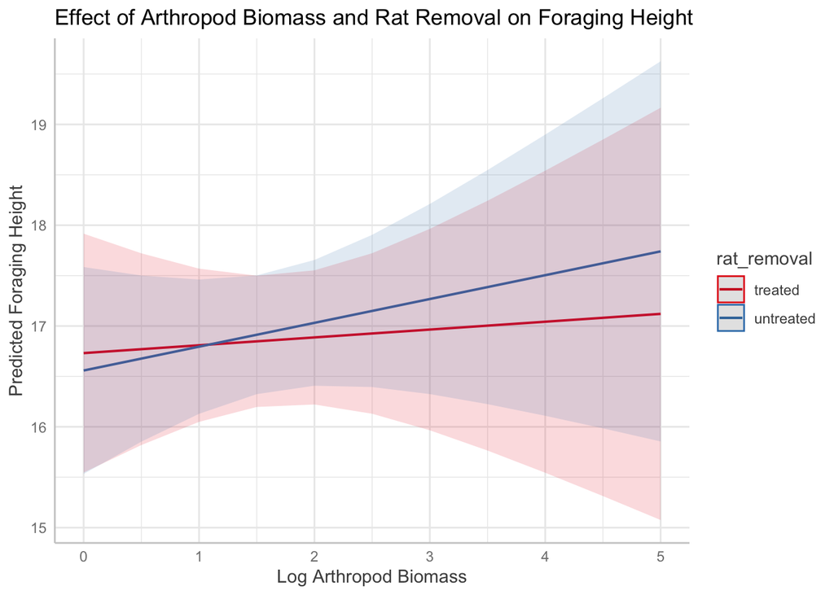

```r
#log_arth_bm with rat_removal interaction (The effects of food availability (arthropod biomass) on our treatment (rat removal))
arth_rat_effects <- ggpredict(all_lm, terms = c("log_arth_bm", "rat_removal"))

# Plot the interaction
plot(arth_rat_effects) +
  ggtitle("Effect of Arthropod Biomass and Rat Removal on Foraging Height") +
  xlab("Log Arthropod Biomass") +
  ylab("Predicted Foraging Height")
```

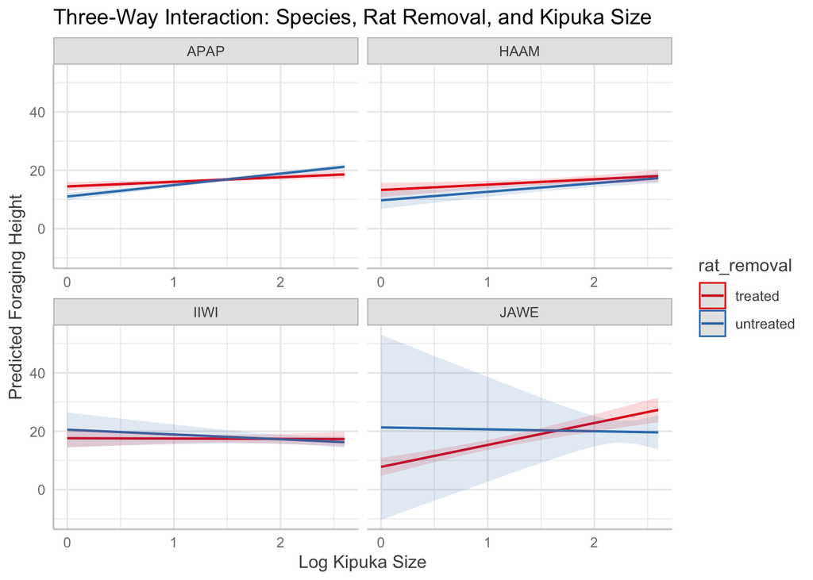

```r
# species, rat_removal, and log_kipuka interaction
three_way_effects <- ggpredict(all_lm, terms = c("log_kipuka", "rat_removal", "species"))

# Plot the interaction
plot(three_way_effects) +
  ggtitle("Three-Way Interaction: Species, Rat Removal, and Kipuka Size") +
  xlab("Log Kipuka Size") +
  ylab("Predicted Foraging Height")
```

Based on these effect plots, when comparing log_kipuka with rat_removal it looks like larger kipuka sizes might enhance foraging height more in nontreated areas compared to treated areas. As for the effect of arthropod biomass, the foraging height for nontreated sites increase more steeply with increasing arthropod biomass compared to treated sites. The threeway interaction plot show that for most species, rat removal has minimal effects ib foraging height across kipuka size. However, for JAWE, rat removal seems to interact with kipuka size allowing birds to forage higher in larger spaces in treated areas. The kipuka size has species specific effects where APAP, HAAM, and JAWE has a postive relationship and IIWI has a negative relationship.

## (5) One thing we have not accounted for in our models is the fact that the study design involves repeated measurements of the same kipuka (and potentially the same birds) over time. We will learn how to properly account for repeated measures, by adding a random effect for kipuka, later in the course. However, there is a different additional predictor that may be helpful in testing the treatment effect. Add DATE as a factor to the linear model from #4. How does the inclusion of the date of sampling alter the model results? Why do you think that is?

```r
#set date as factor
bird <- bird %>%
  mutate(date_factor = factor(date)) %>%
  mutate(year_factor = factor(year))

all_lm_with_date <- lm(foraging_ht_m ~ species * rat_removal * log_kipuka * log_arth_bm + date_factor, data = bird)
summary(all_lm_with_date)
```

```
##
## Call:
## lm(formula = foraging_ht_m ~ species * rat_removal * log_kipuka *
##     log_arth_bm + date_factor, data = bird)
##
## Residuals:
##     Min      1Q  Median      3Q     Max
## -7.7961 -1.5022  0.0722  1.5613  7.6139
##
## Coefficients:
##                                                         Estimate Std. Error
## (Intercept)                                              12.9479     1.1314
## speciesHAAM                                              -3.6683     1.7837
## speciesIIWI                                              -5.7194     2.9105
## speciesJAWE                                               1.1662     2.3816
## rat_removaluntreated                                      3.9042     1.2112
## log_kipuka                                                6.6389     0.9849
## log_arth_bm                                               1.9531     0.7459
## date_factor2012-01-13                                    -0.5734     0.8326
## date_factor2012-01-14                                    -9.9962     1.5935
## date_factor2012-01-15                                   -10.1792     1.4090
## date_factor2012-01-16                                    -2.8944     0.8271
## date_factor2012-01-19                                    -2.5176     1.0884
## date_factor2012-01-20                                    -6.6264     0.9450
## date_factor2012-01-21                                    -3.4743     0.8270
## date_factor2012-01-22                                    -9.0398     1.6712
## date_factor2012-01-23                                    -4.1582     1.0607
## date_factor2012-01-27                                    -8.4091     1.7319
## date_factor2012-01-28                                    -8.6733     1.1610
## date_factor2013-05-10                                   -10.9833     1.5376
## date_factor2013-05-11                                   -11.4066     1.5831
## date_factor2013-05-15                                    -9.0667     1.1025
## date_factor2013-05-16                                    -4.4446     1.1513
## date_factor2013-05-18                                    -6.9595     2.0825
## date_factor2013-05-19                                    -5.9476     0.9462
## date_factor2013-05-23                                    -1.4527     0.9902
## date_factor2013-05-24                                    -4.6705     0.9329
## date_factor2013-05-25                                   -11.9913     1.2157
## date_factor2013-05-27                                    -7.3196     1.5589
## date_factor2013-05-31                                    -7.5810     2.8173
```

[output cut: 80 more lines]

```
## speciesJAWE:rat_removaluntreated:log_arth_bm              0.115 0.908403
## speciesHAAM:log_kipuka:log_arth_bm                       -0.741 0.458937
## speciesIIWI:log_kipuka:log_arth_bm                       -2.018 0.044214 *
## speciesJAWE:log_kipuka:log_arth_bm                        1.090 0.276190
## rat_removaluntreated:log_kipuka:log_arth_bm               5.334 1.60e-07 ***
## speciesHAAM:rat_removaluntreated:log_kipuka:log_arth_bm   1.902 0.057889 .
## speciesIIWI:rat_removaluntreated:log_kipuka:log_arth_bm   2.753 0.006174 **
## speciesJAWE:rat_removaluntreated:log_kipuka:log_arth_bm  -0.208 0.835280
## ---
## Signif. codes:  0 '***' 0.001 '**' 0.01 '*' 0.05 '.' 0.1 ' ' 1
##
## Residual standard error: 2.658 on 406 degrees of freedom
##   (42 observations deleted due to missingness)
## Multiple R-squared:  0.7403, Adjusted R-squared:  0.7039
## F-statistic: 20.31 on 57 and 406 DF,  p-value: < 2.2e-16
```

```r
#adding in the date has a significant effect on foraging height
#aov of new model
Anova(all_lm_with_date)
```

```
## Anova Table (Type II tests)
##
## Response: foraging_ht_m
##                                             Sum Sq  Df  F value    Pr(>F)
## species                                      70.44   3   3.3242  0.019756 *
## rat_removal                                 166.26   1  23.5373 1.749e-06 ***
## log_kipuka                                  879.44   1 124.5014 < 2.2e-16 ***
## log_arth_bm                                  17.65   1   2.4987  0.114721
## date_factor                                2321.98  26  12.6432 < 2.2e-16 ***
## species:rat_removal                          39.86   3   1.8812  0.132109
## species:log_kipuka                           31.23   3   1.4738  0.221104
## rat_removal:log_kipuka                       44.33   1   6.2764  0.012626 *
## species:log_arth_bm                           3.73   3   0.1762  0.912477
## rat_removal:log_arth_bm                     477.71   1  67.6288 2.696e-15 ***
## log_kipuka:log_arth_bm                        0.10   1   0.0136  0.907327
## species:rat_removal:log_kipuka               91.65   3   4.3251  0.005118 **
## species:rat_removal:log_arth_bm              12.14   3   0.5731  0.632978
## species:log_kipuka:log_arth_bm               20.55   3   0.9696  0.406982
## rat_removal:log_kipuka:log_arth_bm          481.45   1  68.1584 2.142e-15 ***
## species:rat_removal:log_kipuka:log_arth_bm   67.97   3   3.2073  0.023104 *
## Residuals                                  2867.85 406
## ---
## Signif. codes:  0 '***' 0.001 '**' 0.01 '*' 0.05 '.' 0.1 ' ' 1
```

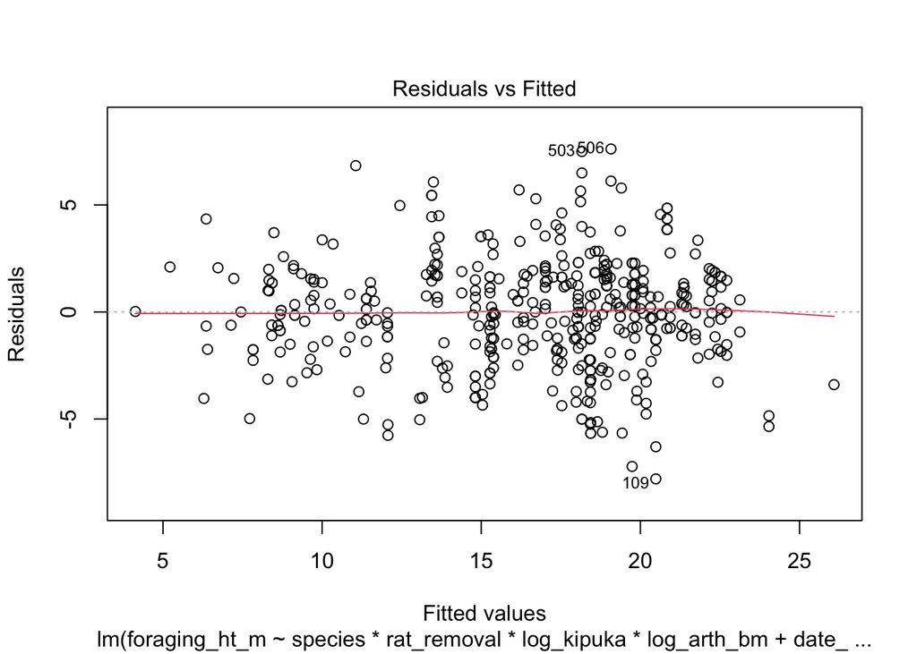

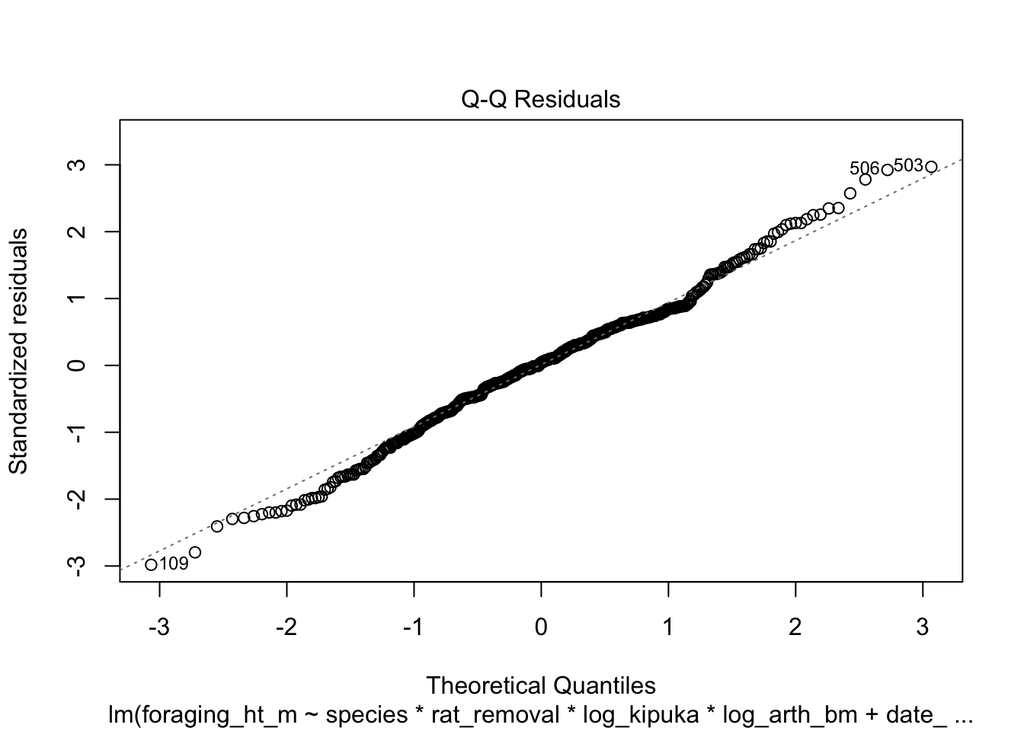

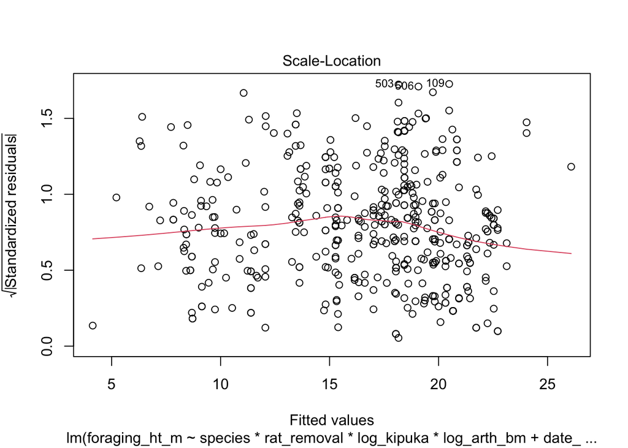

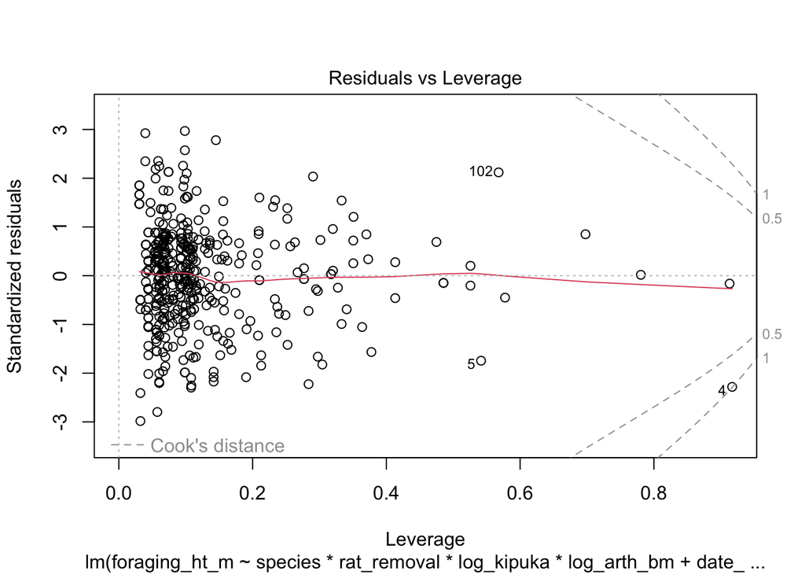

```r
# Generate effects for the model
effects_plot <- ggpredict(all_lm_with_date, terms = c("log_kipuka", "log_arth_bm", "species", "rat_removal"))

# Plot the effects
plot(all_lm_with_date)
```